### Notas de aula de Mecânica Quântica Autor: Jonas Maziero

# Precessão de spin

Aqui veremos o 1º, e mais simples, exemplo de aplicação dos postulados da Mecânica Quântica, um sistema de dois níveis. Em particular, descreveremos o postulados dos estados e das medidas em ação. Também exemplificaremos a descrição da dinâmica quântica nas representações de Schrödinger e de Heisenberg.

## Hamiltoniano

Considerando o protótipo clássico de dipolo magnético, a espira de corrente, obtemos a seguinte relação entre momento de dipolo magnético e momento angular: \begin{equation} \vec{\mu} = \frac{q}{2m}\vec{L}. \end{equation} Para descrever "*distribuições mais complicadas de corrente*", corrigimos esta expressão usando o **fator giromagnético** $g$, que deve ser determinado experimentalmente para cada partícula em específico, e.g. \begin{align} & g(\text{elétron}) = g_{e} \approx −2.0023, \\ & g(\text{próton}) = g_{p} \approx 5.586, \\ & g(\text{nêutron}) = g_{n} \approx −3.826. \end{align} Assim \begin{equation} \vec{\mu} = \frac{gq}{2m}\vec{L}. \end{equation}

Quando nos referimos ao *momento angular intrínseco*, o spin, usamos em geral o símbolo $\vec{S}$, que por sua vez é escrito em termos de um outro operador $\vec{\sigma}$ como \begin{equation} \vec{S}=\frac{\hbar}{2}\vec{\sigma}. \end{equation} Juntando tudo obtemos: \begin{equation} \vec{\mu} = \frac{\hbar gq}{4m}\vec{\sigma}. \end{equation}

A *energia potencial* de interação entre um momento e um campo magnético $\vec{B}=B\hat{n}_{B}$ é dada por: \begin{align} U & = -\vec{\mu}\cdot\vec{B} \\ & = -\frac{\hbar gqB}{4m}\vec{\sigma}.\hat{n}_{B} \\ & =: -\frac{\hbar\omega}{2}\vec{\sigma}.\hat{n}_{B} \\ & \equiv H, \end{align} desconsiderando a energia cinética. Acima definimos a *frequência de Larmor*: \begin{equation} \omega := \frac{g q B}{2m}, \end{equation} que nos fornece a intensidade da interação entre $\vec{\mu}$ e $\vec{B}$.

Por sua vez, a força sobre uma partícula interagindo dessa forma será \begin{align} \vec{F} & = -\vec{\nabla}U \\ & = \sum_{j=x,y,z}\mu_{j}\vec{\nabla}B_{j} \\ & = \sum_{j=x,y,z}\mu_{j}\left(\hat{i}\partial_{x}B_{j}+\hat{j}\partial_{y}B_{j}+\hat{k}\partial_{z}B_{j}\right). \end{align}

## Estados e observáveis de um spin 1/2

Em experimentos de Stern e Gerlach (ESG) (https://www.nobelprize.org/prizes/physics/1943/stern/lecture/), observa-se a quantização do spin fazendo-se partículas de spin 1/2 atravessar uma região com um gradiente de campo magnético, e observando que somente dois feixes de partículas bem separados resultam dessa interação (veja algumas animações: https://youtu.be/rg4Fnag4V-E e https://youtu.be/PH1FbkLVJU4).

[figure not shown]

Vamos começar olhando para um detalhe que normalmente não é discutido profundamente em textos de MQ. Nesses textos, quando se explica os ESG considera-se e.g. o gradiente de campo magnético \begin{equation} \vec{B}= \beta z\hat{k} \end{equation} com $\beta$ constante. No entanto, esse campo não satisfaz a equação de Maxwell \begin{equation} \nabla\cdot\vec{B}=0, \end{equation} e não é, portanto, fisicamente aceitável.

Um exemplo de campo magnético que satisfaz essa equação é \begin{equation} \vec{B}=\beta(x\hat{i}-z\hat{k}). \end{equation} Mas é notável que nesse caso a força fica escrita como \begin{align} \vec{F} & =-\nabla U = -\nabla (-\mu\cdot\vec{B}) = \nabla\beta(\mu_{x}x-\mu_{z}z) \\ & = \beta(\mu_{x}\hat{i} - \mu_{z}\hat{k}) = F_x \hat{i} + F_z\hat{k}. \end{align} Mas essa força vai separar o feixe de partículas em quatro feixes, um para cada possível par de valores das componentes do momento magnético $(\mu_{x},\mu_{z})$. Uma maneira de focar na medida de uma única componente é aplicar um campo constante muito forte na direção na qual queremos medir o momento magnético. Um exemplo de tal campo seria (veja a referência 2): \begin{equation} \vec{B}=\beta x\hat{i}+(\alpha-\beta z)\hat{k} \end{equation} com $$\beta \ll \alpha.$$ Observo, no entanto, que na aplicação na interpretação de medidas em MQ, essa exclusão pela média nula de $F_{x}$ complica a interpretação quântica de colapso da função de onda. Não obstante, a seguir assumo que se possa fazer medidas de componente de momento magnético em qualquer direção que se queira.

### Componente $z$

*OBS:* Em qualquer direção que se coloque o gradiente de campo magnético, teremos dois feixes desviados com proporções iguais. Por conseguinte, os autovalores terão a *mesma magnitude* para medida da camponente do spin em qualquer direção.

### Componente $x$

Determina-se experimentalmente que se prepararmos os quantons no estado $|z_{+}\rangle$ ou $|z_{-}\rangle$, através da medida de $\sigma_{z}$, e os fizermos passar por um gradiente de $\vec{B}$ na direção $x$, metade deles serão desviados pra cima e metade pra baixo. Como $\sigma_{x}$ é um operador Hermitiano, $\{|x_{\pm}\rangle\}$ é uma base ortonormal e podemos escrever \begin{cases} |z_{+}\rangle = c_{+}^{+}|x_{+}\rangle+c_{+}^{-}|x_{-}\rangle, \\ |z_{-}\rangle = c_{-}^{+}|x_{+}\rangle+c_{-}^{-}|x_{-}\rangle. \end{cases} Note que acima usamo o sinal no super-índice (índice de cima) para denotar a qual estado da base estamos nos referindo ($|x_+\rangle$ ou $|x_-\rangle$). O sub-índice (índice de baixo) é usado para denotar qual estado estamos expandindo naquela base ($|z_+\rangle$ ou $|z_-\rangle$).

Usando a regra de Born, temos que \begin{equation} Pr(x_{\pm}|z_{\pm})=|c_{\pm}^{\pm}|^{2}=1/2\therefore |c_{\pm}^{\pm}|=1/\sqrt{2}. \end{equation} Note que na notação acima consideramos todas as combinações de estados preparados e resultados de medida em uma mesma expressão, o que é feito colocando $\pm$ no super-índice e no sub-índice.

Podemos iniciar assumindo que $$c_{\pm}^{\pm}\in\mathbb{R}\therefore c_{\pm}^{\pm}=\pm 1/\sqrt{2}$$ e que $$|z_{+}\rangle = (1/\sqrt{2})|x_{+}\rangle+(1/\sqrt{2})|x_{-}\rangle.$$ Agora, $\sigma_{z}$ é um operador Hermitiano e assim $\{|z_{\pm}\rangle\}$ é uma base ortonormal, e portanto devemos ter $\langle z_+|z_-\rangle = 0$, o que pode ser obtido fazendo $$|z_{-}\rangle = (1/\sqrt{2})|x_{+}\rangle-(1/\sqrt{2})|x_{-}\rangle.$$ Somando ou subtraindo $\{|z_{\pm}\rangle\}$ obtemos \begin{equation} |x_{\pm}\rangle = \sqrt{1/2}|z_{+}\rangle \pm \sqrt{1/2}|z_{-}\rangle. \end{equation}

Assim, nesse caso o observável fica escrito como: \begin{align} \sigma_{x} &= x_{+}|x_{+}\rangle\langle x_{+}| + x_{-}|x_{-}\rangle\langle x_{-}| \\ & = (+1)|x_{+}\rangle\langle x_{+}| + (-1)|x_{-}\rangle\langle x_{-}| \\ & = (\sqrt{1/2}|z_{+}\rangle + \sqrt{1/2}|z_{-}\rangle)(\sqrt{1/2}\langle z_{+}| + \sqrt{1/2}\langle z_{-}|) - (\sqrt{1/2}|z_{+}\rangle - \sqrt{1/2}|z_{-}\rangle)(\sqrt{1/2}\langle z_{+}| - \sqrt{1/2}\langle z_{-}|) \\ & = (1/2)(|z_{+}\rangle\langle z_{+}| + |z_{+}\rangle\langle z_{-}| + |z_{-}\rangle\langle z_{+}| + |z_{-}\rangle\langle z_{-}|) - (1/2)(|z_{+}\rangle\langle z_{+}| - |z_{+}\rangle\langle z_{-}| - |z_{-}\rangle\langle z_{+}| + |z_{-}\rangle\langle z_{-}|) \\ & = |z_{+}\rangle\langle z_{-}| + |z_{-}\rangle\langle z_{+}| \\ & = \begin{bmatrix} 0 & 1 \\ 1 & 0 \end{bmatrix}, \end{align} na base $\{|z_{+}\rangle,|z_{-}\rangle\}$.

### Componente $y$

Aqui começamos escrevendo \begin{equation} |y_{\pm}\rangle = d_{\pm}^{+}|z_{+}\rangle + d_{\pm}^{-}|z_{-}\rangle. \end{equation} Também é um fato empírico que se preparamos os quantons em qualquer um dos estados $\{|y_{\pm}\rangle\}$ e os fizermos passar por um gradiente de $\vec{B}$ na direção $z$, a probabilidade de desvio pra cima ou pra baixo é $1/2$. Assim, pela regra de Born, devemos ter que: \begin{equation} Pr(z_{\pm}|y_{\pm})=|d_{\pm}^{\pm}|^{2}=1/2 \therefore |d_{\pm}^{\pm}|=1/\sqrt{2}. \end{equation} Assim, se usamos $$d_{\pm}^{\pm}=|d_{\pm}^{\pm}|e^{i\phi_{\pm}^{\pm}}=(1/\sqrt{2})e^{i\phi_{\pm}^{\pm}},$$ teremos que \begin{cases} |y_{+}\rangle = (e^{i\phi_{+}^{+}}/\sqrt{2})(|z_{+}\rangle + e^{i(\phi_{+}^{-}-\phi_{+}^{+})}|z_{-}\rangle) \equiv (1/\sqrt{2})(|z_{+}\rangle + e^{i\phi_{+}}|z_{-}\rangle), \\ |y_{-}\rangle = (e^{i\phi_{-}^{+}}/\sqrt{2})(|z_{+}\rangle + e^{i(\phi_{-}^{-}-\phi_{-}^{+})}|z_{-}\rangle) \equiv (1/\sqrt{2})(|z_{+}\rangle + e^{i\phi_{-}}|z_{-}\rangle). \end{cases} Como $\sigma_{y}$ é um observável, devemos ter \begin{align} & \langle y_{\pm}|y_{\mp}\rangle\propto 1+e^{\pm i(\phi_{+}-\phi_{-})}=1+\cos(\phi_{+}-\phi_{-})\pm i\sin(\phi_{+}-\phi_{-})=0 \\ & \therefore\ \phi_{+}-\phi_{-}=\pi. \end{align}

Usando e.g. $\langle x_{+}|=(1/\sqrt{2})(\langle z_{+}|+\langle z_{-}|)$ e o fato empírico $Pr(x_{+}|y_{+})=1/2$ teremos \begin{align} & |\langle x_{+}|y_{+}\rangle|^{2} = (1/4)|1+e^{i\phi_{+}}|^{2}=(1/2)(1+\cos\phi_{+})=1/2 \therefore \cos\phi_{+}=0 \\ & \therefore\ \phi_{+}=\pi/2=-\phi_{-}. \end{align} Por conseguinte \begin{cases} |y_{+}\rangle = (1/\sqrt{2})(|z_{+}\rangle + i|z_{-}\rangle), \\ |y_{-}\rangle = (1/\sqrt{2})(|z_{+}\rangle - i|z_{-}\rangle), \end{cases} com $i=\sqrt{-1}$. Isso nos leva à seguinte matriz que representa a componente $y$ do spin 1/2: \begin{align} \sigma_{y} &= y_{+}|y_{+}\rangle\langle y_{+}| + y_{-}|y_{-}\rangle\langle y_{-}| \\ & = (+1)|y_{+}\rangle\langle y_{+}| + (-1)|y_{-}\rangle\langle y_{-}| \\ & = (\sqrt{1/2}|z_{+}\rangle + i\sqrt{1/2}|z_{-}\rangle)(\sqrt{1/2}\langle z_{+}| - i\sqrt{1/2}\langle z_{-}|) - (\sqrt{1/2}|z_{+}\rangle - i\sqrt{1/2}|z_{-}\rangle)(\sqrt{1/2}\langle z_{+}| + i\sqrt{1/2}\langle z_{-}|) \\ & = (1/2)(|z_{+}\rangle\langle z_{+}| - i|z_{+}\rangle\langle z_{-}| + i|z_{-}\rangle\langle z_{+}| + |z_{-}\rangle\langle z_{-}|) - (1/2)(|z_{+}\rangle\langle z_{+}| + i|z_{+}\rangle\langle z_{-}| - i|z_{-}\rangle\langle z_{+}| + |z_{-}\rangle\langle z_{-}|) \\ & = -i|z_{+}\rangle\langle z_{-}| + i|z_{-}\rangle\langle z_{+}| \\ & = \begin{bmatrix} 0 & -i \\ i & 0 \end{bmatrix}, \end{align} na base $\{|z_{+}\rangle,|z_{-}\rangle\}$.

### Componente na direção $\hat{n}$

Agora, para descrever a componente do spin 1/2 em uma *direção qualquer*, consideramos o vetor de Pauli \begin{equation} \vec{\sigma}=\hat{i}\sigma_{x}+\hat{j}\sigma_{y}+\hat{k}\sigma_{z} \end{equation} e o versor naquela direção ($\theta\in[0,\pi]$, $\phi\in[0,2\pi]$), \begin{align} \hat{n} & = \hat{i}n_{x}+\hat{j}n_{y}+\hat{k}n_{z} \\ & = \hat{i}\sin\theta\cos\phi+\hat{j}\sin\theta\sin\phi+\hat{k}\cos\theta, \end{align} para escrever \begin{align} \hat{n}\cdot\vec{\sigma} & = \sigma_{x}\sin\theta\cos\phi + \sigma_{y}\sin\theta\sin\phi + \sigma_{z}\cos\theta \\ & = \begin{bmatrix} \cos\theta & e^{-i\phi}\sin\theta \\ e^{i\phi}\sin\theta & -\cos\theta \end{bmatrix}, \end{align} cujos autovalores são $n_{\pm}=\pm 1$ e autovetores podem ser expressos como: \begin{cases} |n_{+}\rangle = \cos(\theta/2)|z_{+}\rangle + e^{i\phi}\sin(\theta/2)|z_{-}\rangle, \\ |n_{-}\rangle = \sin(\theta/2)|z_{+}\rangle - e^{i\phi}\cos(\theta/2)|z_{-}\rangle. \end{cases}

OBS. As matrizes de Pauli $\sigma_{x},\sigma_{y},\sigma_{z}$ formam uma base para matrizes $2\mathrm{x}2$ com traço nulo, como é o caso de $\hat{n}\cdot\vec{\sigma}$.

## Incompatibilidade quântica e medidas quânticas

Pode-se verificar (veja o código Sympy abaixo) que as matrizes de Pauli satisfazem a seguinte relação de comutação: $$[\sigma_j,\sigma_k] = 2i\epsilon_{jkl}\sigma_l \equiv 2i\sum_{l=1}^3\epsilon_{jkl}\sigma_l,$$ com $j,k,l=1,2,3$ e $\epsilon_{jkl}$ é o símbolo de Levi-Civita (que é a função sinal para 3 números, como pode ser visto em detalhes em https://github.com/jonasmaziero/algebra_linear).

```python
from sympy import Matrix, init_printing
init_printing(use_unicode=True)
s1 = Matrix([[0,1],[1,0]]); s2 = Matrix([[0,-1j],[1j,0]]); s3 = Matrix([[1,0],[0,-1]])
s1, s2, s3
```

$\displaystyle \left( \left[\begin{matrix}0 & 1\\1 & 0\end{matrix}\right], \ \left[\begin{matrix}0 & - 1.0 i\\1.0 i & 0\end{matrix}\right], \ \left[\begin{matrix}1 & 0\\0 & -1\end{matrix}\right]\right)$

```python
def comm(x,y):
    return x*y - y*x

comm(s1,s2), comm(s1,s3), comm(s2,s3)
```

$\displaystyle \left( \left[\begin{matrix}2.0 i & 0\\0 & - 2.0 i\end{matrix}\right], \ \left[\begin{matrix}0 & -2\\2 & 0\end{matrix}\right], \ \left[\begin{matrix}0 & 2.0 i\\2.0 i & 0\end{matrix}\right]\right)$

Ou seja, as 3 componentes em $\mathbb{R}^3$ do momento angular de spin de um spin 1/2 são observáveis incompatíveis, e portanto não podem compartilhar a mesma base de autovetores. Na verdade, teremos que \begin{align} [\hat{n}\cdot\vec{\sigma},\hat{n}'\cdot\vec{\sigma}] & = \Big[\sum_{j=1}^3 n_j\sigma_j,\sum_{k=1}^3 n'_k \sigma_k \Big] \\ & = \sum_{j,k=1}^3 n_j n'_k[\sigma_j,\sigma_k] \\ & = \sum_{j,k=1}^3 n_j n'_k 2i\epsilon_{jkl}\sigma_l \\ & = 2i\big(n_1 n'_2 \epsilon_{123}\sigma_3 + n_2 n'_1 \epsilon_{213}\sigma_3 + n_1 n'_3 \epsilon_{132}\sigma_2 + n_3 n'_1 \epsilon_{312}\sigma_2 + n_2 n'_3 \epsilon_{231}\sigma_1 + n_3 n'_2 \epsilon_{321}\sigma_1\big) \\ & = 2i\big((n_1 n'_2 - n_2 n'_1)\sigma_3 + (-n_1 n'_3 + n_3 n'_1)\sigma_2 + (n_2 n'_3 - n_3 n'_2)\sigma_1\big) \\ & = 2i\big((\sin\theta\cos\phi \sin\theta'\sin\phi' - \sin\theta\sin\phi \sin\theta'\cos\phi')\sigma_3 + (-\sin\theta\cos\phi \cos\theta' + \cos\theta \sin\theta'\cos\phi')\sigma_2 \\ & \hspace{1cm} + (\sin\theta\sin\phi \cos\theta' - \cos\theta \sin\theta'\sin\phi')\sigma_1\big) \\ & = 2i\big(\sin\theta\sin\theta'\sin(\phi'-\phi)\sigma_3 + (-\sin\theta\cos\phi \cos\theta' + \cos\theta \sin\theta'\cos\phi')\sigma_2 \\ & \hspace{1cm} + (\sin\theta\sin\phi \cos\theta' - \cos\theta \sin\theta'\sin\phi')\sigma_1\big) \\ & = 2i\big(\sin\theta\sin\theta'\sin(\phi'-\phi)\sigma_3 + 2^{-1}\big(\sin(\theta+\theta')(-\cos\phi + \cos\phi') + \sin(\theta-\theta')(\cos\phi + \cos\phi')\big)\sigma_2 \\ & \hspace{1cm} + 2^{-1}\big(\sin(\theta+\theta')(\sin\phi - \sin\phi') + \sin(\theta-\theta')(\sin\phi + \sin\phi')\big)\sigma_1\big) \\ \end{align} em que \begin{align} & \hat{n} = (n_1,n_2,n_3) = (\sin\theta\cos\phi,\sin\theta\sin\phi,\cos\theta),\\ & \hat{n}' = (n'_1,n'_2,n'_3) = (\sin\theta'\cos\phi',\sin\theta'\sin\phi',\cos\theta'). \end{align} Pode-se verificar (veja o código abaixo) que se $(\theta'=\theta,\ \phi'=\phi)\ \therefore\ \hat{n}'=\hat{n}$ ou $(\theta'=\pi-\theta,\ \phi'=\pi+\phi)\ \therefore\ \hat{n}'=-\hat{n}$, então $[\hat{n}\cdot\vec{\sigma},\hat{n}'\cdot\vec{\sigma}]=0.$ Ou seja, medidas da componente de um spin 1/2 são companíveis se tiverem alinhadas ou antialinhadas, que na prática são feitas usando um gradiente de campo magnético colocado na mesma direção.

```python
from sympy import symbols, sin, cos, simplify
th, ph, xi, et = symbols('theta phi xi eta')
ns = sin(th)*cos(ph)*s1 + sin(th)*sin(ph)*s2 + cos(th)*s3
nls = sin(xi)*cos(et)*s1 + sin(xi)*sin(et)*s2 + cos(xi)*s3
simplify(ns), simplify(nls)
```

$\displaystyle \left( \left[\begin{matrix}\cos{\left(\theta \right)} & 1.0 e^{- i \phi} \sin{\left(\theta \right)}\\1.0 e^{i \phi} \sin{\left(\theta \right)} & - \cos{\left(\theta \right)}\end{matrix}\right], \ \left[\begin{matrix}\cos{\left(\xi \right)} & 1.0 e^{- i \eta} \sin{\left(\xi \right)}\\1.0 e^{i \eta} \sin{\left(\xi \right)} & - \cos{\left(\xi \right)}\end{matrix}\right]\right)$

```python
simplify(comm(ns,nls))
```

$\displaystyle \left[\begin{matrix}2.0 i \sin{\left(\theta \right)} \sin{\left(\xi \right)} \sin{\left(\eta - \phi \right)} & - 2.0 e^{- i \phi} \sin{\left(\theta \right)} \cos{\left(\xi \right)} + 2.0 e^{- i \eta} \sin{\left(\xi \right)} \cos{\left(\theta \right)}\\- 2.0 e^{i \eta} \sin{\left(\xi \right)} \cos{\left(\theta \right)} + 2.0 e^{i \phi} \sin{\left(\theta \right)} \cos{\left(\xi \right)} & - 2.0 i \sin{\left(\theta \right)} \sin{\left(\xi \right)} \sin{\left(\eta - \phi \right)}\end{matrix}\right]$

```python
def f_ns(th,ph):
    return sin(th)*cos(ph)*s1 + sin(th)*sin(ph)*s2 + cos(th)*s3

simplify(comm(f_ns(th,ph),f_ns(th,ph)))
```

$\displaystyle \left[\begin{matrix}0 & 0\\0 & 0\end{matrix}\right]$

```python
from sympy import pi
simplify(comm(f_ns(th,ph),f_ns(pi-th,pi+ph)))
```

$\displaystyle \left[\begin{matrix}0 & 0\\0 & 0\end{matrix}\right]$

A física clássica nos induz a pensar que observáveis tem valores bem definidos independentemente de se observamos esses valores ou não. No entanto, para sistemas quânticos essa lógica não é válida. Para ilustrar isso, consideremos medidas sequenciais de componentes de um spin 1/2. Consideremos spin 1/2 em um estado desconhecido passando por um gradiente de campo magnético na direção $z$ ($SG_z$), depois passando por um gradiente de campo magnético na direção $x$ ($SG_x$) e depois passando por $SG_z$ novamente: $$|?\rangle \xrightarrow[]{SG_z} \begin{cases} |z_+\rangle \xrightarrow[]{SG_x} \begin{cases}Pr(|x_+\rangle) = 1/2 \xrightarrow[]{SG_z} \begin{cases}Pr(|z_+\rangle) = 1/2 \\ Pr(|z_-\rangle) = 1/2 \end{cases} \\ Pr(|x_-\rangle) = 1/2 \xrightarrow[]{SG_z} \begin{cases}Pr(|z_+\rangle) = 1/2 \\ Pr(|z_-\rangle) = 1/2 \end{cases} \end{cases} \\ |z_-\rangle \xrightarrow[]{SG_x} \begin{cases}Pr(|x_+\rangle) = 1/2 \xrightarrow[]{SG_z} \begin{cases}Pr(|z_+\rangle) = 1/2 \\ Pr(|z_-\rangle) = 1/2 \end{cases} \\ Pr(|x_-\rangle) = 1/2 \xrightarrow[]{SG_z} \begin{cases}Pr(|z_+\rangle) = 1/2 \\ Pr(|z_-\rangle) = 1/2 \end{cases} \end{cases} \end{cases}.$$

Ou seja, mesmo sabendo que o spin 1/2 está e.g. no estado $|z_+\rangle$ depois da 1ª medida, se medirmos um observável incompatível a $\sigma_z$ (no exemplo medimos $\sigma_x$), "apagaremos" a informação sobre o valor de $\sigma_z$. Posteriormente, ao medirmos $\sigma_z$ podemos obter qualquer um dos seus valores de forma aleatória, e no caso considerado com mesma probabilidade.

## Precessão de spin na representação de Schrödinger (RS)

Vamos considerar a evolução temporal do spin 1/2 quando este está submetido a um campo magnético constante na direção $z$, i.e., $\vec{B}=B\hat{k}$. Nesse caso o Hamiltoniano será \begin{equation} H = -\frac{\hbar\omega}{2}\vec{\sigma}\cdot\hat{k} = -\frac{\hbar\omega}{2}\sigma_{z} = \begin{bmatrix} -\frac{\hbar\omega}{2} & 0 \\ 0 & \frac{\hbar\omega}{2} \end{bmatrix} = -\frac{\hbar\omega}{2}|z_{+}\rangle\langle z_{+}| + \frac{\hbar\omega}{2}|z_{-}\rangle\langle z_{-}|. \end{equation}

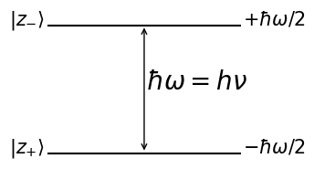

```python
from matplotlib import pyplot as plt

fig = plt.figure(figsize=(3,2))
plt.hlines(-1,0,1,color='black')
plt.text(-0.2,-1,r'$|z_{+}\rangle$',color='black', fontsize=15)
plt.text(1.01,-1,r'$-\hbar\omega/2$',color='black', fontsize=15)
plt.hlines(1,0,1,color='black')
plt.text(-0.2,1,r'$|z_{-}\rangle$',color='black', fontsize=15)
plt.text(1.01,1,r'$+\hbar\omega/2$',color='black', fontsize=15)
plt.annotate("",xy=(0.5,-1),xytext=(0.5,1),arrowprops=dict(arrowstyle="<->"))
plt.text(0.51,0,r'$\hbar\omega=h\nu$', fontsize=20); plt.axis('off')
plt.show()
```

Como o Hamiltoniano é independente do tempo, o operador de evolução temporal (que é solução de $i\hbar\partial_{t}U_{t}=H_{t}U_{t}$) pode ser escrito como \begin{equation} U_{t} = e^{-iHt/\hbar} = e^{i\hbar\omega\sigma_{z}t/2\hbar} = e^{i\omega\sigma_{z}t/2}. \end{equation}

Vamos considerar que o sistema foi preparado no estado inicial \begin{equation} |\psi_{0}^{S}\rangle:=|n_{+}\rangle. \end{equation} O estado evoluído do sistema será: \begin{align} |\psi_{t}^{S}\rangle & = U_{t}|\psi_{0}^{S}\rangle = U_{t}|n_{+}\rangle \\ & = U_{t}\left(\cos(\theta/2)|z_{+}\rangle + e^{i\phi}\sin(\theta/2)|z_{-}\rangle\right) \\ & = \cos(\theta/2)U_{t}|z_{+}\rangle + e^{i\phi}\sin(\theta/2)U_{t}|z_{-}\rangle \\ &= \cos(\theta/2)e^{i\omega\sigma_{z}t/2}|z_{+}\rangle + e^{i\phi}\sin(\theta/2)e^{i\omega\sigma_{z}t/2}|z_{-}\rangle \\ & = \cos(\theta/2)e^{i\omega t/2}|z_{+}\rangle + e^{i\phi}\sin(\theta/2)e^{-i\omega t/2}|z_{-}\rangle. \end{align}

Como não mudamos as probabilidades calculadas via regra de Born pela multiplicação de um vetor de estado por uma fase global, vamos considerar \begin{align} |\psi_{t}^{S}\rangle & \equiv e^{-i\omega t/2}|\psi_{t}^{S}\rangle \\\ & = \cos(\theta/2)|z_{+}\rangle + e^{i(\phi -\omega t)}\sin(\theta/2)|z_{-}\rangle \\ & =: \cos(\theta_{t}/2)|z_{+}\rangle + e^{i\phi_{t}}\sin(\theta_{t}/2)|z_{-}\rangle, \end{align} com \begin{equation} \theta_{t}=\theta=\text{constante} \text{ e } \phi_{t}=\phi-\omega t. \end{equation}

#### Componente $z$:

Lembrando que na RS os observáveis não mudam com $t$, abaixo calculamos as probabilidades, valores médios e desvios padrões para as três componentes do spin 1/2. Será útil observar que $\sigma_{j}^{2}=\mathbb{I}$, para $j=1,2,3$, e portanto que $\langle\sigma_{j}^{2}\rangle=\langle\psi_{t}^{S}|\mathbb{I}|\psi_{t}^{S}\rangle=1$. Começando com a componente $z$ do spin: \begin{align} Pr(z_{+}(t)) & = |\langle z_{+}|\psi_{t}^{S}\rangle|^{2} = |\langle z_{+}|(\cos(\theta_{t}/2)|z_{+}\rangle + e^{i\phi_{t}}\sin(\theta_{t}/2)|z_{-}\rangle)|^{2} \\ & = \cos^{2}(\theta_{t}/2) = (1+\cos\theta_{t})/2, \\ Pr(z_{-}(t)) & = 1- Pr(z_{+}(t)) = (1-\cos\theta_{t})/2, \\ \langle\sigma_{z}(t)\rangle & = (-1)Pr(z_{-}(t))+(+1)Pr(z_{+}(t)) = Pr(z_{+}(t))-Pr(z_{-}(t)) = \cos\theta_{t}, \\ & \sigma_{\sigma_{z}} = \sqrt{\langle\sigma_{z}^{2}\rangle-\langle\sigma_{z}\rangle^{2}} = \sqrt{1-\cos^{2}\theta_{t}} = \sin\theta_{t}. \end{align} Note que a distribuição de probabilidades para $\sigma_{z}$ não muda como o tempo.

#### Componente $x$:

\begin{align} Pr(x_{+}(t)) & = \left|\langle x_{+}|\psi_{t}^{S}\rangle\right|^{2} = \left|\langle x_{+}|(\cos(\theta_{t}/2)|z_{+}\rangle + e^{i\phi_{t}}\sin(\theta_{t}/2)|z_{-}\rangle)\right|^{2} \\ & = \left|(\cos(\theta_{t}/2) + e^{i\phi_{t}}\sin(\theta_{t}/2))/\sqrt{2}\right|^{2} \\ & = (\cos^{2}(\theta_{t}/2))+\sin^{2}(\theta_{t}/2)+\cos(\theta_{t}/2)\sin(\theta_{t}/2)(e^{i\phi_{t}}+e^{-i\phi_{t}}))/2 \\ & = \left(1+2\cos(\theta_{t}/2)\sin(\theta_{t}/2)\cos\phi_{t})/2 = (1+\sin\theta_{t}\cos\phi_{t}\right)/2, \\ Pr(x_{-}(t)) & = 1- Pr(x_{+}(t)) = (1-\sin\theta_{t}\cos\phi_{t})/2, \\ \langle\sigma_{x}(t)\rangle & = (-1)Pr(x_{-}(t))+(+1)Pr(x_{+}(t)) = Pr(x_{+}(t))-Pr(x_{-}(t)) = \sin\theta_{t}\cos\phi_{t}, \\ & \sigma_{\sigma_{x}} = \sqrt{\langle\sigma_{x}^{2}\rangle-\langle\sigma_{x}\rangle^{2}} = \sqrt{1-\sin^{2}\theta_{t}\cos^{2}\phi_{t}}. \end{align}

Acima usamos $\langle x_{+}|z_{\pm}\rangle=1/\sqrt{2}$.

#### Componente $y$:

\begin{align} Pr(y_{+}(t)) & = \left|\langle y_{+}|\psi_{t}^{S}\rangle\right|^{2} = \left|\langle y_{+}|(\cos(\theta_{t}/2)|z_{+}\rangle + e^{i\phi_{t}}\sin(\theta_{t}/2)|z_{-}\rangle)\right|^{2} \\ & = \left|(\cos(\theta_{t}/2) - ie^{i\phi_{t}}\sin(\theta_{t}/2))/\sqrt{2}\right|^{2} \\ & = \left(\cos^{2}(\theta_{t}/2))+\sin^{2}(\theta_{t}/2)-\cos(\theta_{t}/2)\sin(\theta_{t}/2)i(e^{i\phi_{t}}-e^{-i\phi_{t}})\right)/2 \\ & = (1+2\cos(\theta_{t}/2)\sin(\theta_{t}/2)\sin\phi_{t})/2 = (1+\sin\theta_{t}\sin\phi_{t})/2, \\ Pr(y_{-}(t)) & = 1- Pr(y_{+}(t)) = (1-\sin\theta_{t}\sin\phi_{t})/2, \\ \langle\sigma_{y}(t)\rangle & = (-1)Pr(y_{-}(t))+(+1)Pr(y_{+}(t)) = Pr(y_{+}(t))-Pr(y_{-}(t)) = \sin\theta_{t}\sin\phi_{t}, \\ & \sigma_{\sigma_{y}} = \sqrt{\langle\sigma_{y}^{2}\rangle-\langle\sigma_{y}\rangle^{2}} = \sqrt{1-\sin^{2}\theta_{t}\sin^{2}\phi_{t}}. \end{align}

Acima usamos $\langle y_{+}|z_{+}\rangle=1/\sqrt{2}$ e $\langle y_{+}|z_{-}\rangle=-i/\sqrt{2}$.

```python
import math
from ipywidgets import interactive, interact, fixed, interact_manual, widgets
import numpy as np

def spin_precession(th,ph):
    N = 200; dx = (2*math.pi)/N; x = np.zeros(N)
    y1 = np.zeros(N); y2 = np.zeros(N); y3 = np.zeros(N)
    y1s = np.zeros(N); y2s = np.zeros(N); y3s = np.zeros(N)
    for j in range(0,N):
        x[j] = j*dx
        y1s[j] = math.sqrt(1-math.sin(th)**2*math.cos(ph-x[j])**2)
        y1[j] = math.sin(th)*math.cos(ph-x[j])
        y2[j] = math.sin(th)*math.sin(ph-x[j]); y3[j] = math.cos(th)
        y2s[j] = math.sqrt(1-math.sin(th)**2*math.sin(ph-x[j])**2)
        y3s[j] = math.sin(th)
    fig = plt.figure(figsize=(7,5))
    plt.plot(x,y1,color='blue'); plt.plot(x,y2,color='black')
    plt.plot(x,y3,color='red')
    plt.plot(x,y1s,color='blue',linestyle='--')
    plt.plot(x,y2s,color='black',linestyle='--')
    plt.plot(x,y3s,color='red',linestyle='--')
    plt.xlabel(r'$\omega t$')
    plt.legend((r'$\langle\sigma_{x}\rangle$',\
                r'$\langle\sigma_{y}\rangle$',\
                r'$\langle\sigma_{z}\rangle$',\
                r'$\sigma_{\sigma_{x}}$',\
                r'$\sigma_{\sigma_{y}}$',r'$\sigma_{\sigma_{z}}$')\
               ,loc=(1.01,0.2))
    plt.ylim(-1.1,1.1); plt.show()
interactive(spin_precession,th=(0,math.pi,0.05),ph=(0,4*math.pi,0.1))
```

```
interactive(children=(FloatSlider(value=1.55, description='th', max=3.141592653589793, step=0.05), FloatSlider…
```

### Representação do estado de um spin 1/2 em $\mathbb{R}^{3}$

Notemos que \begin{align} & (\langle\sigma_{x}(t)\rangle,\langle\sigma_{y}(t)\rangle,\langle\sigma_{y}(t)\rangle) = (\sin\theta_{t}\cos\phi_{t},\sin\theta_{t}\sin\phi_{t},\cos\theta_{t}) \\ & = (n_{x}(t),n_{y}(t),n_{z}(t)) = \hat{n}_{t}, \end{align} é a direção para onde aponta o vetor em $\mathbb{R}^{3}$ que corresponde ao estado quântico $|\psi_{t}^{S}\rangle$ do spin 1/2 no instante de tempo $t$, pois se medirmos a componente do spin nessa direção obteremos $n_{+}$ com probabilidade igual a $1$, i.e., \begin{equation} Pr(n_{+}(t)) = 1. \end{equation}

Na realidade, essa evolução temporal quântica em $\mathbb{C}^{2}$ é equivalente a uma rotação em $\mathbb{R}^{3}$ em torno do eixo $z$ por um ângulo $-\omega t$: \begin{align} R_{z}(-\omega t)\hat{n}_{0} & = \begin{bmatrix} \cos\omega t & \sin\omega t & 0 \\ -\sin\omega t & \cos\omega t & 0 \\ 0 & 0 & 1 \end{bmatrix}\begin{bmatrix}\sin\theta\cos\phi \\ \sin\theta\sin\phi \\ \cos\theta \end{bmatrix} \\ & = \begin{bmatrix}\cos\omega t\sin\theta\cos\phi+\sin\omega t\sin\theta\sin\phi \\ -\sin\omega t\sin\theta\cos\phi+\cos\omega t\sin\theta\sin\phi \\ \cos\theta \end{bmatrix} \\ & = \begin{bmatrix}\sin\theta\cos(\phi-\omega t) \\ \sin\theta\sin(\phi-\omega t) \\ \cos\theta \end{bmatrix} =\begin{bmatrix} n_{x}(t) \\ n_{y}(t) \\ n_{z}(t) \end{bmatrix} = \hat{n}_{t}. \end{align}

OBS. Para mais detalhes sobre matrizes de rotação, veja https://github.com/jonasmaziero/teoria_de_grupos/blob/main/04_U_O_Sp.ipynb.

## Precessão de spin na representação de Heisenberg (RH)

Na RH, se o spin 1/2 foi preparado no estado $|n_{+}\rangle=\cos(\theta/2)|z_{+}\rangle+e^{i\phi}\sin(\theta/2)|z_{-}\rangle$, usaremos este mesmo vetor para calcular probabilidades em tempos posteriores. Por outro lado, evoluiremos os oberváveis. Para isso usaremos novamente: \begin{equation} U_{t} = e^{i\omega\sigma_{z}t/2}= e^{i\omega t/2}|z_{+}\rangle\langle z_{+}| + e^{-i\omega t/2}|z_{-}\rangle\langle z_{-}|. \end{equation}

#### Componente $z$:

\begin{align} |z_{+}(t)\rangle & = U_{t}^{\dagger}|z_{+}\rangle = (e^{-i\omega t/2}|z_{+}\rangle\langle z_{+}| + e^{i\omega t/2}|z_{-}\rangle\langle z_{-}|)|z_{+}\rangle \\ & = e^{-i\omega t/2}|z_{+}\rangle\langle z_{+}|z_{+}\rangle + e^{i\omega t/2}|z_{-}\rangle\langle z_{-}|z_{+}\rangle \\ & = e^{-i\omega t/2}|z_{+}\rangle, \\ |z_{-}(t)\rangle & = U_{t}^{\dagger}|z_{-}\rangle = e^{i\omega t/2}|z_{-}\rangle. \end{align}

Ou seja, estes autovetores só ganham uma fase global. Teremos assim que as probabilidades são constantes para medidas de $\sigma_{z}$: \begin{align} Pr(z_{+}(t)) & = |\langle z_{+}(t)|n_{+}\rangle|^{2} = |e^{i\omega t/2}\langle z_{+}|n_{+}\rangle|^{2} = |\langle z_{+}|n_{+}\rangle|^{2} = Pr(z_{+}) = (1+\cos\theta)/2, \\ Pr(z_{-}(t)) & = 1-Pr(z_{+}(t)) = (1-\cos\theta)/2. \end{align}

#### Componente $x$:

\begin{align} |x_{+}(t)\rangle & = U_{t}^{\dagger}|x_{+}\rangle = (e^{-i\omega t/2}|z_{+}\rangle\langle z_{+}| + e^{i\omega t/2}|z_{-}\rangle\langle z_{-}|)(|z_{+}\rangle+|z_{-}\rangle)/\sqrt{2} \\ & = (e^{-i\omega t/2}|z_{+}\rangle + e^{i\omega t/2}|z_{-}\rangle)/\sqrt{2} = e^{-i\omega t/2}(|z_{+}\rangle + e^{i\omega t}|z_{-}\rangle)/\sqrt{2}, \\ |x_{-}(t)\rangle & = U_{t}^{\dagger}|x_{-}\rangle = e^{-i\omega t/2}(|z_{+}\rangle - e^{i\omega t}|z_{-}\rangle)/\sqrt{2}. \end{align}

As probabilidades serão: \begin{align} Pr(x_{+}(t)) & = |\langle x_{+}(t)|n_{+}\rangle|^{2} \\ & = \left|e^{i\omega t/2}(\langle z_{+}| + e^{-i\omega t}\langle z_{-}|)(\cos(\theta/2)|z_{+}\rangle+e^{i\phi}\sin(\theta/2)|z_{-}\rangle)/\sqrt{2}\right|^{2} \\ & = \left|\cos(\theta/2) + e^{i(\phi-\omega t)}\sin(\theta/2)\right|^{2}/2 \\ & = (\cos^{2}(\theta/2) + \sin(\theta/2)\cos(\theta/2)(e^{i(\phi-\omega t)}+e^{-i(\phi-\omega t)}) + \sin^{2}(\theta/2))/2 \\ & = (1+\sin\theta\cos(\phi-\omega t))/2. \\ Pr(x_{-}(t)) & = 1-Pr(x_{+}(t)) = (1-\sin\theta\cos(\phi-\omega t))/2. \end{align}

#### Componente $y$:

\begin{align} |y_{+}(t)\rangle & = U_{t}^{\dagger}|y_{+}\rangle = (e^{-i\omega t/2}|z_{+}\rangle\langle z_{+}| + e^{i\omega t/2}|z_{-}\rangle\langle z_{-}|)(|z_{+}\rangle+i|z_{-}\rangle)/\sqrt{2} \\ & = (e^{-i\omega t/2}|z_{+}\rangle + ie^{i\omega t/2}|z_{-}\rangle)/\sqrt{2} = e^{-i\omega t/2}(|z_{+}\rangle + ie^{i\omega t}|z_{-}\rangle)/\sqrt{2}, \\ |y_{-}(t)\rangle & = U_{t}^{\dagger}|y_{-}\rangle = e^{-i\omega t/2}(|z_{+}\rangle - ie^{i\omega t}|z_{-}\rangle)/\sqrt{2}. \end{align}

As probabilidades serão: \begin{align} Pr(y_{+}(t)) & = |\langle y_{+}(t)|n_{+}\rangle|^{2} \\ & = \left|e^{i\omega t/2}(\langle z_{+}| - ie^{-i\omega t}\langle z_{-}|)(\cos(\theta/2)|z_{+}\rangle+e^{i\phi}\sin(\theta/2)|z_{-}\rangle)/\sqrt{2}\right|^{2} \\ & = \left|\cos(\theta/2) - ie^{i(\phi-\omega t)}\sin(\theta/2)\right|^{2}/2 \\ & = \left(\cos^{2}(\theta/2) + i\sin(\theta/2)\cos(\theta/2)(e^{-i(\phi-\omega t)}-e^{i(\phi-\omega t)})+\sin^{2}(\theta/2)\right)/2 \\ & = (1+\sin\theta\sin(\phi-\omega t))/2. \\ Pr(y_{-}(t)) & = 1-Pr(y_{+}(t)) = (1-\sin\theta\sin(\phi-\omega t))/2. \end{align}

Obtivemos assim os mesmos resultados para as probabilidades que na RS. Os valores médios e desvios padrões são obtidos como na RS.

### Precessão de spin a partir da equação de Heisenberg

Aqui usaremos a eq. de Heisenberg \begin{equation} i\hbar\partial_{t}O_{t}^{H}=[O_{t}^{H},H_{t}^{H}]+i\hbar\partial_{t}^{H}O_{t}^{S}. \end{equation} Nesse caso \begin{equation} \partial_{t}^{H}O_{t}^{S} = U_{t}^{\dagger}(\partial_{t}^{S}O_{t}^{S})U_{t}=U_{t}^{\dagger}(\mathbb{O})U_{t}=\mathbb{O}, \end{equation} pois os observáveis considerados, $\{\sigma_{j}^{S}\}_{j=x,y,z}$, não dependem explicitamente do tempo. Usaremos também a relação de comutação geral entre matrizes de Pauli: \begin{equation} [\sigma_{j}^{S},\sigma_{k}^{S}]=2i\epsilon_{jkl}\sigma_{l}^{S} \therefore [\sigma_{j}^{H},\sigma_{k}^{H}]=2i\epsilon_{jkl}\sigma_{l}^{H}. \end{equation} Precisaremos também do Hamiltoniano \begin{equation} H_{t}^{H} = -\frac{\hbar\omega}{2}\sigma_{z}^{H}. \end{equation}

Teremos assim que \begin{align} & i\hbar\partial_{t}\sigma_{x}^{H} = [\sigma_{x}^{H},H^{H}] =[\sigma_{x}^{H},-\frac{\hbar\omega}{2}\sigma_{z}^{H}] = -\frac{\hbar\omega}{2}2i\epsilon_{132}\sigma_{y}^{H} \\ & \Rightarrow \partial_{t}\sigma_{x}^{H} = \omega\sigma_{y}^{H}. \\ & i\hbar\partial_{t}\sigma_{y}^{H} = [\sigma_{y}^{H},H^{H}] =[\sigma_{y}^{H},-\frac{\hbar\omega}{2}\sigma_{z}^{H}] = -\frac{\hbar\omega}{2}2i\epsilon_{231}\sigma_{y}^{H} \\ & \Rightarrow \partial_{t}\sigma_{y}^{H} = -\omega\sigma_{x}^{H}. \\ & i\hbar\partial_{t}\sigma_{z}^{H} = [\sigma_{z}^{H},H^{H}] =[\sigma_{z}^{H},-\frac{\hbar\omega}{2}\sigma_{z}^{H}] = \mathbb{0} \\ & \Rightarrow \sigma_{z}^{H} = \sigma_{z}^{S}. \end{align} Uma possibilidade de solução é \begin{align} \sigma_{x}^{H} &= \sigma_{x}^{S}\cos\omega t + \sigma_{y}^{S}\sin\omega t, \\ \sigma_{y}^{H} &= -\sigma_{x}^{S}\sin\omega t + \sigma_{y}^{S}\cos\omega t. \end{align} Ou, na forma matricial \begin{equation} \begin{bmatrix} \sigma_{x}^{H} \\ \sigma_{y}^{H} \end{bmatrix} = \begin{bmatrix} \cos\omega t & \sin\omega t \\ -\sin\omega t & \cos\omega t \end{bmatrix}\begin{bmatrix} \sigma_{x}^{S} \\ \sigma_{y}^{S} \end{bmatrix}. \end{equation} OBS. Note que a matriz que relaciona os "vetores de observáveis" é a matriz de rotação em $\mathbb{R}^{2}$.

Para obter os valores médios vamos usar: \begin{cases} \sigma_{x}|z_{+}\rangle = |z_{-}\rangle \text{, }\sigma_{x}|z_{-}\rangle = |z_{+}\rangle, \\ \sigma_{y}|z_{+}\rangle = i|z_{-}\rangle \text{, }\sigma_{y}|z_{-}\rangle = -i|z_{+}\rangle, \\ \sigma_{z}|z_{+}\rangle = |z_{+}\rangle \text{, }\sigma_{z}|z_{-}\rangle = -|z_{-}\rangle. \end{cases} Assim \begin{align} \langle\sigma_{x}\rangle_{n_{+}} & = \langle n_{+}|\sigma_{x}|n_{+}\rangle \\ & = \langle n_{+}|\sigma_{x}(\cos(\theta/2)|z_{+}\rangle+e^{i\phi}\sin(\theta/2)|z_{-}\rangle) \\ & = (\cos(\theta/2)\langle z_{+}|+e^{-i\phi}\sin(\theta/2)\langle z_{-}|)(\cos(\theta/2)|z_{-}\rangle+e^{i\phi}\sin(\theta/2)|z_{+}\rangle) \\ & = \sin(\theta/2)\cos(\theta/2)(e^{i\phi}+e^{-i\phi}) \\ & = 2\sin(\theta/2)\cos(\theta/2)\cos\phi \\ & = \sin\theta\cos\phi, \\ \langle\sigma_{y}\rangle_{n_{+}} & = \langle n_{+}|\sigma_{y}|n_{+}\rangle \\ & = \langle n_{+}|\sigma_{y}(\cos(\theta/2)|z_{+}\rangle+e^{i\phi}\sin(\theta/2)|z_{-}\rangle) \\ & = (\cos(\theta/2)\langle z_{+}|+e^{-i\phi}\sin(\theta/2)\langle z_{-}|)(i\cos(\theta/2)|z_{-}\rangle-ie^{i\phi}\sin(\theta/2)|z_{+}\rangle) \\ & = -i\sin(\theta/2)\cos(\theta/2)(e^{i\phi}-e^{-i\phi}) \\ & = -i2\sin(\theta/2)\cos(\theta/2)i\sin\phi \\ & = \sin\theta\sin\phi, \\ \langle\sigma_{z}\rangle_{n_{+}} & = \langle n_{+}|\sigma_{z}|n_{+}\rangle \\ & = \langle n_{+}|\sigma_{z}(\cos(\theta/2)|z_{+}\rangle+e^{i\phi}\sin(\theta/2)|z_{-}\rangle) \\ & = (\cos(\theta/2)\langle z_{+}|+e^{-i\phi}\sin(\theta/2)\langle z_{-}|)(\cos(\theta/2)|z_{+}\rangle-e^{i\phi}\sin(\theta/2)|z_{-}\rangle) \\ & = \cos^{2}(\theta/2)-\sin^{2}(\theta/2) \\ & = \cos\theta. \end{align}

OBS. Vale mencionar que, na RH, se usamos as equações de Heisenberg, não obtemos as probabilidades, mas somente os valores médios.

### Precessão de spin para $[H_t,H_{t'}]=0$

Vamos considerar um exemplo de sistema físico para o qual o operador hamiltoniano comuta em tempos diferentes, e que por conseguinte podemos utilizar a forma $U_t = e^{-\frac{i}{\hbar}\int_0^t H_{t'}dt'}$ para o operador de evolução temporal.

Vamos considerar um quanton de spin 1/2 sujeito a um campo magnético constante no espaço mas dependente do tempo $$\vec{B}_t = B_t \hat{k}.$$ Lembrando, o momento de dipolo magnético pode ser escrito como $$\vec{\mu} = \frac{g q}{2m}\vec{S} = \frac{\hbar g q}{4m}\vec{\sigma}.$$ Com isso, o hamiltoniano de interação do momento de dipolo magnético com o campo magnético é \begin{align} H_t & = -\vec{\mu}\cdot\vec{B}_t = -\frac{\hbar g q}{4m}\vec{\sigma}\cdot B_t \hat{k} \\ & =: -\frac{\hbar\omega_t}{2}\sigma_z, \end{align} em que definimos a frequência $$\omega_t := \frac{g qB_t}{2m}.$$ Note que essa frequência depende da forma de $B_t$. Se este e.g. varia senoidalmente, a frequência também varia dessa forma. Se e.g. $B_t = B_0 t$, então a frequência aumentará linearmente com o tempo. Mas para as contas que faremos na sequência, não precisaremos especificar a forma da dependência do campo magnético com o tempo.

Começamos verificando que esse hamiltoniano comuta em tempos diferentes: \begin{align} [H_t,H_{t'}] & = \big[-\frac{\hbar\omega_t}{2}\sigma_z,-\frac{\hbar\omega_{t'}}{2}\sigma_z\big] = \frac{\hbar^2 \omega_t\omega_{t'}}{4}[\sigma_z,\sigma_z] \\ & = 0. \end{align}

Vimos que nesta situação o operador de evolução temporal $$U_t = e^{-\frac{i}{\hbar}\int_{0}^{t}H_{t'}dt'}$$ é solução da equação de Schrödiner $i\hbar\partial_t U_t = H_t U_t.$ Com isso, vem que \begin{align} U_t & = e^{-\frac{i}{\hbar}\int_{0}^{t}(-\hbar\omega_{t'}\sigma_z /2)dt'} = e^{i\big(\int_{0}^{t}\omega_{t'}dt'\big)\sigma_z /2} \\ & =: e^{if_t \sigma_z /2} \\ & = e^{if_t /2}|z_+\rangle\langle z_+| + e^{-if_t /2}|z_-\rangle\langle z_-|, \end{align} em que definimos a função escalar do tempo $$f_t := \int_{0}^{t}\omega_{t'}dt'.$$

Com isso, começando com um estado de spin geral na direção $\hat{n}$, i.e., $$|\psi_0\rangle = |n_+\rangle = \cos(\theta/2)|z_+\rangle + e^{i\phi}\sin(\theta/2)|z_-\rangle,$$ teremos que o estado evoluído será dado por \begin{align} |\psi_t\rangle & = U_t|\psi_0\rangle \\ & = \big(e^{if_t /2}|z_+\rangle\langle z_+| + e^{-if_t /2}|z_-\rangle\langle z_-|\big)\big(\cos(\theta/2)|z_+\rangle + e^{i\phi}\sin(\theta/2)|z_-\rangle\big) \\ & = e^{if_t /2}\cos(\theta/2)|z_+\rangle + e^{-if_t /2}e^{i\phi}\sin(\theta/2)|z_-\rangle \\ & = e^{if_t /2}\big(\cos(\theta/2)|z_+\rangle + e^{i(\phi-f_t)}\sin(\theta/2)|z_-\rangle\big) \\ & \equiv \cos(\theta/2)|z_+\rangle + e^{i(\phi-f_t)}\sin(\theta/2)|z_-\rangle, \end{align} em que desconsideramos a fase global $e^{if_t /2}$. Se usarmos a representação de estados quânticos de sistemas de 2 níveis na esfera de Bloch (isomorfismo $SU(2)\leftrightarrow SO(3)$), vemos que a representação deste estado em $\mathbb{R}^3$ precessa em torno da direção $z$ positiva, com o ângulo azimutal dado por $$\phi_t = \phi_0 - f_t.$$

Por exemplo, se o campo magnético aumenta linearmente com o tempo, $$B_t = B_0 t,$$ então $$\omega_t = \frac{gqB_0}{2m}t=\omega_0 t$$ e $$f_{t} = \int_{0}^{t}\omega_0 t'dt' = \frac{\omega_0 t^2}{2}.$$ Assim $$\phi_t = \phi_0 - f_t = \phi_0 - \frac{\omega_0 t^2}{2}.$$

# Exercícios

$1.$ Verifique que um campo magnético $\vec{B} = \beta z\hat{k}$, com $\beta$ sendo uma constante real, não satisfaz a equação de Maxwell $\vec{\nabla}\cdot\vec{B}=0$. Verifique que $\vec{B}=\beta(x\hat{i}-z\hat{k})$ e $\vec{B}=\beta x\hat{i}+(\alpha-\beta z)\hat{k}$ satisfazem essa equação, com $\alpha$ sendo uma constante real.

$2.$ Verifique que $|x_{\pm}\rangle = \sqrt{1/2}|z_{+}\rangle \pm \sqrt{1/2}|z_{-}\rangle$ e que eles formam uma base ortonormal. Verifique também que $|z_{+}\rangle = (1/\sqrt{2})(|y_{+}\rangle+|y_{-}\rangle)$, $|z_{-}\rangle = (-i/\sqrt{2})(|y_{+}\rangle-|y_{-}\rangle)$, $|y_{\pm}\rangle = ((1\pm i)/2)|x_{+}\rangle + ((1\mp i)/2)|x_{-}\rangle$ e $|x_{\pm}\rangle = ((1\mp i)/2)|y_{+}\rangle + ((1\pm i)/2)|y_{-}\rangle$.

$3.$ Verifique que os autovalores de $\hat{n}\cdot\vec{\sigma} = \begin{bmatrix} \cos\theta & e^{-i\phi}\sin\theta \\ e^{i\phi}\sin\theta & -\cos\theta \end{bmatrix}$ são $n_{\pm}=\pm 1$ e que seus autovetores podem ser expressos como $|n_{+}\rangle = \cos(\theta/2)|z_{+}\rangle + e^{i\phi}\sin(\theta/2)|z_{-}\rangle$ e $|n_{-}\rangle = \sin(\theta/2)|z_{+}\rangle - e^{i\phi}\cos(\theta/2)|z_{-}\rangle$.

$4.$ Verifique que se multiplicarmos o estado do sistema por uma fase global, não modificamos as probabilidades, i.e., mostre que $Pr(o_{j}|\psi)=Pr(o_{j}|\phi)$ para $|\phi\rangle:=e^{i\xi}|\psi\rangle$ com $\xi\in\mathbb{R}.$

$5.$ No contexto da descrição da precessão de spin na representação de Schrödinger, obtenha o estado evoluído, as probabilidades, os valores médios e os desvios padrões considerando um campo magnético constante aplicado na direção $x$, e com o spin 1/2 preparado inicialmente em um estado genérico $|n_{+}\rangle$. Verifique também que $R_{x}(-\omega t)\hat{n}_{0}=\hat{n}_{t}$ com $\hat{n}_{t}=\begin{bmatrix} \langle\sigma_{x}\rangle_{\psi_{t}} & \langle\sigma_{y}\rangle_{\psi_{t}} & \langle\sigma_{z}\rangle_{\psi_{t}} \end{bmatrix}^{T}$.

$6.$ Verifique a relação de comutação geral entre matrizes de Pauli: $[\sigma_{j},\sigma_{k}]=2i\epsilon_{jkl}\sigma_{l}$.

$7.$ Verifique que \begin{cases} \sigma_{x}|z_{+}\rangle = |z_{-}\rangle \text{, }\sigma_{x}|z_{-}\rangle = |z_{+}\rangle, \\ \sigma_{y}|z_{+}\rangle = i|z_{-}\rangle \text{, }\sigma_{y}|z_{-}\rangle = -i|z_{+}\rangle, \\ \sigma_{z}|z_{+}\rangle = |z_{+}\rangle \text{, }\sigma_{z}|z_{-}\rangle = -|z_{-}\rangle. \end{cases}

$8.$ No contexto da descrição da precessão de spin na representação de Heisenberg, calcule probabilidades e valores médios evoluídos no tempo nas direções $x,y,z$ considerando um campo magnético constante aplicado na direção $x$, e com o spin 1/2 preparado inicialmente em um estado genérico $|n_{+}\rangle$.

$9.$ Para $H=-\frac{\hbar\omega}{2}\sigma_{x},$, obtenha $\langle\sigma_{x}(t)\rangle,\langle\sigma_{y}(t)\rangle,\langle\sigma_{x}(t)\rangle$ a partir da solução da equação de Heisenberg. Use $\langle\sigma_x(0)\rangle = \sin\theta\cos\phi$, $\langle\sigma_y(0)\rangle = \sin\theta\sin\phi$ e $\langle\sigma_z(0)\rangle = \cos\theta$.

$10.$ As três componentes do momento angular de spin de uma partícula de spin $1$ são representadas pelos seguintes operadores Hermitianos: \begin{equation} S_{x} = \frac{\hbar}{\sqrt{2}}\begin{bmatrix} 0 & 1 & 0 \\ 1 & 0 & 1 \\ 0 & 1 & 0 \end{bmatrix}\text{, } S_{y} = \frac{\hbar}{\sqrt{2}}\begin{bmatrix} 0 & -i & 0 \\ i & 0 & -i \\ 0 & i & 0 \end{bmatrix}\text{, } S_{z} = \hbar\begin{bmatrix} 1 & 0 & 0 \\ 0 & 0 & 0 \\ 0 & 0 & -1 \end{bmatrix}. \\ \end{equation} Essas matrizes tem espectro de autovalores $-\hbar,0,+\hbar$. Os autovetores normalizados de $S_{x}$ são \begin{equation} |x_{-\hbar}\rangle = \frac{1}{2}\begin{bmatrix} 1 \\ -\sqrt{2} \\ 1 \end{bmatrix}\text{, } |x_{0}\rangle = \frac{1}{\sqrt{2}}\begin{bmatrix} -1 \\ 0 \\ 1 \end{bmatrix}\text{, } |x_{+\hbar}\rangle = \frac{1}{2}\begin{bmatrix} 1 \\ \sqrt{2} \\ 1 \end{bmatrix}. \end{equation} Dito que a componente do spin dessa partícula na direção $x$ foi medida e que foi obtido o valor $0$, calcule as probabilidades dos diferentes valores de $S_{z}$.

$11.$ Dado que os autovetores de $S_{y}$ são \begin{equation} |y_{-\hbar}\rangle = \frac{1}{2}\begin{bmatrix} -1 \\ i\sqrt{2} \\ 1 \end{bmatrix}\text{, } |y_{0}\rangle = \frac{1}{\sqrt{2}}\begin{bmatrix} 1 \\ 0 \\ 1 \end{bmatrix}\text{, } |y_{+\hbar}\rangle = \frac{1}{2}\begin{bmatrix} -1 \\ -i\sqrt{2} \\ 1 \end{bmatrix}, \end{equation} considere uma partícula de spin $1$ sujeita a um campo magnético constante na direção $z$ positiva e preparada inicialmente no estado $|y_{0}\rangle$. Calcule o estado evoluído no tempo, $|\psi_{t}\rangle$, e a probabilidade $Pr(y_{0}|\psi_{t})$.

$12.$ Considere uma partícula de spin $s=2$, cujas componentes são descritas pelas seguintes matrizes Hermitianas: \begin{equation} S_{x}=\frac{\hbar}{2}\begin{bmatrix} 0 & 2 & 0 & 0 & 0 \\ 2 & 0 & \sqrt{6} & 0 & 0 \\ 0 & \sqrt{6} & 0 & \sqrt{6} & 0 \\ 0 & 0 & \sqrt{6} & 0 & 2 \\ 0 & 0 & 0 & 2 & 0 \end{bmatrix} \text{, } S_{y}=\frac{\hbar}{2}\begin{bmatrix} 0 & -2i & 0 & 0 & 0 \\ 2i & 0 & -\sqrt{6}i & 0 & 0 \\ 0 & \sqrt{6}i & 0 & -\sqrt{6}i & 0 \\ 0 & 0 & \sqrt{6}i & 0 & -2i \\ 0 & 0 & 0 & 2i & 0 \end{bmatrix}\text{, } S_{z}=\hbar\begin{bmatrix} 2 & 0 & 0 & 0 & 0 \\ 0 & 1 & 0 & 0 & 0 \\ 0 & 0 & 0 & 0 & 0 \\ 0 & 0 & 0 & -1 & 0 \\ 0 & 0 & 0 & 0 & -2 \end{bmatrix}. \end{equation} Considere que a componente $x$ desse spin foi medida e que se obteve o valor $2\hbar$, cujo autovetor correspondente é $|x_{2\hbar}\rangle=\begin{bmatrix} 1 & 2 & \sqrt{6} & 2 & 1 \end{bmatrix}^{T}/4$. Se a componente $z$ for medida na sequência, quais são as probabilidades para os seus possíveis valores?

$13.$ Para os estados de polarização da luz (direções de oscilação do campo elétrico) teremos o análogo do que vimos para as componentes do momento magnético intrínseco de uma partícula de spin 1/2, i.e., a base ortonormal de autovetores de $\sigma_{z}$ é $\{|\leftrightarrow\rangle,|\updownarrow\rangle\}$ (polarizações horizontal e vertical), a base ortonormal de autovetores de $\sigma_{x}$ é $\{|\nearrow\rangle=(|\leftrightarrow\rangle+|\updownarrow\rangle)/\sqrt{2},|\nwarrow\rangle=(|\leftrightarrow\rangle-|\updownarrow\rangle)/\sqrt{2}\}$ (polarizações diagonal direita e diagonal esquerda) e a base ortonormal de autovetores de $\sigma_{y}$ é $\{|\circlearrowright\rangle=(|\leftrightarrow\rangle+i|\updownarrow\rangle)/\sqrt{2},|\circlearrowleft\rangle=(|\leftrightarrow\rangle-i|\updownarrow\rangle)/\sqrt{2}\}$ (polarizações circular direita e circular esquerda). Considere analisadores de polarização $P_{x},P_{y},P_{z}$, que fazem o processo de medida análogo ao feito pelos aparelhos de Stern-Gerlach $SG_{x},SG_{y},SG_{z}$, respectivamente. Calcule as probabilidades para os possíveis resultados das seguintes sequências de preparações e medidas: \begin{align} (a) \hspace{1cm} & |\leftrightarrow\rangle \hspace{0.3cm} \underrightarrow{P_{z}} \hspace{0.3cm} |?\rangle \text{;}\\ (b) \hspace{1cm} & |\leftrightarrow\rangle \hspace{0.3cm} \underrightarrow{P_{z}} \hspace{0.3cm} |?\rangle \hspace{0.3cm} \underrightarrow{P_{x}} \hspace{0.3cm} |?\rangle \text{;} \\ (c) \hspace{1cm} & |\leftrightarrow\rangle \hspace{0.3cm} \underrightarrow{P_{z}} \hspace{0.3cm} |?\rangle \hspace{0.3cm} \underrightarrow{P_{x}} \hspace{0.3cm} |?\rangle \hspace{0.3cm} \underrightarrow{P_{y}} \hspace{0.3cm} |?\rangle. \end{align}

$14.$ Se spins 3/2 vindos de um forno passam por um gradiente efetivo de campo magnético na direção $\hat{x}$ (lembre que nesse caso temos efetivamente $\langle\vec{F}\rangle=\langle(-\vec{\nabla}U)\rangle=\langle(-\vec{\nabla}(-\vec{\mu}\cdot\vec{B}))\rangle\propto \mu_x$), em quantas direções diferentes eles podem ser desviados? Se um desses spins foi desviado pra cima na direção $\hat{x}$ com o maior ângulo de desvio possível, em que estado quântico $|\psi\rangle$ esse spin foi preparado? Se fizermos esse spin, preparado inicialmente nesse estado $|\psi\rangle$, passar novamente por um gradiente efetivo de campo magnético na direção $\hat{x}$, qual será o estado $|\phi\rangle$ do spin depois da interação com o gradiente de campo magnético? Se fizermos o spin 3/2 preparado nesse estado $|\phi\rangle$ passar por um gradiente efetivo de campo magnético na direção $\hat{y}$, qual é a probabilidade do spin ter o maior ângulo possível de desvio nessa direção?

$15.$ Considere o quanton de spin 3/2 sujeito a um campo magnético constante, no tempo e no espaço, na direção $\hat{z}$, o que efetivamente nos fornece um hamiltoniano $H=-\omega S_z$. Considere o spin 3/2 preparado inicialmente no estado $|\psi\rangle$ da questão $14$. Calcule o estado do spin 3/2 em um instante de tempo $t$ qualquer, seguindo a representação de Schrödinger da dinâmica quântica.

$16.$ Considerando o mesmo hamiltoniano da questão $15$, na representação de Heisenberg, usando a equação de Heisenberg, calcule $S_x^H(t)$, $S_y^H(t)$ e $S_z^H(t)$. Dica: $[S_x^H,S_z^H]=-i\hbar S_y^H$, $[S_y^H,S_z^H]=i\hbar S_x^H$.

# Material suplementar

Para um spin $s$ qualquer, os operadores que descrevem as componentes $x$, $y$ e $z$ desse spin $\vec{S}$ tem os seguinte elementos não nulos \begin{align} & S^x_{j,k} = 2^{-1}\hbar(\delta_{j,k+1}+\delta_{j+1,k})\sqrt{(s+1)(j+k-1)-jk}, \\ & S^y_{j,k} = 2^{-1}i\hbar(\delta_{j,k+1}-\delta_{j+1,k})\sqrt{(s+1)(j+k-1)-jk}, \\ & S^z_{j,k} = \hbar(s+1-j)\delta_{j,k} = \hbar(s+1-k)\delta_{j,k}, \\ \end{align} com $$1\le j\le 2s+1,\ 1\le k\le 2s+1.$$

Para $s=1/2$ temos $$S_x = \frac{\hbar}{2}\begin{bmatrix} 0 & 1 \\ 1 & 0 \end{bmatrix},\ S_y = \frac{\hbar}{2}\begin{bmatrix} 0 & -i \\ i & 0 \end{bmatrix},\ S_z = \frac{\hbar}{2}\begin{bmatrix} 1 & 0 \\ 0 & -1 \end{bmatrix}.$$

Para $s=1$ temos $$S_x = \frac{\hbar}{2}\begin{bmatrix} 0 & \sqrt{2} & 0 \\ \sqrt{2} & 0 & \sqrt{2} \\ 0 & \sqrt{2} & 0 \end{bmatrix},\ S_y = \frac{\hbar}{2}\begin{bmatrix} 0 & -i\sqrt{2} & 0 \\ i\sqrt{2} & 0 & -i\sqrt{2} \\ 0 & i\sqrt{2} & 0 \end{bmatrix},\ S_z = \frac{\hbar}{2}\begin{bmatrix} 2 & 0 & 0 \\ 0 & 0 & 0 \\ 0 & 0 & -2 \end{bmatrix}.$$

Para $s=3/2$ temos $$S_x = \frac{\hbar}{2}\begin{bmatrix} 0 & \sqrt{3} & 0 & 0 \\ \sqrt{3} & 0 & 2 & 0 \\ 0 & 2 & 0 & \sqrt{3} \\ 0 & 0 & \sqrt{3}& 0 \end{bmatrix},\ S_y = \frac{\hbar}{2}\begin{bmatrix} 0 & -i\sqrt{3} & 0 & 0 \\ i\sqrt{3} & 0 & -2i & 0 \\ 0 & 2i & 0 & -i\sqrt{3} \\ 0 & 0 & i\sqrt{3}& 0 \end{bmatrix},\ S_z = \frac{\hbar}{2}\begin{bmatrix} 3 & 0 & 0 & 0 \\ 0 & 1 & 0 & 0 \\ 0 & 0 & -1 & 0 \\ 0 & 0 & 0 & -3 \end{bmatrix}.$$

Para $s=2$ temos $$S_x = \frac{\hbar}{2}\begin{bmatrix} 0 & 2 & 0 & 0 & 0 \\ 2 & 0 & \sqrt{6} & 0 & 0 \\ 0 & \sqrt{6} & 0 & \sqrt{6} & 0 \\ 0 & 0 & \sqrt{6} & 0 & 2 \\ 0 & 0 & 0 & 2 & 0 \end{bmatrix},\ S_y = \frac{\hbar}{2}\begin{bmatrix} 0 & -2i & 0 & 0 & 0 \\ 2i & 0 & -i\sqrt{6} & 0 & 0 \\ 0 & i\sqrt{6} & 0 & -i\sqrt{6} & 0 \\ 0 & 0 & i\sqrt{6} & 0 & -2i \\ 0 & 0 & 0 & 2i & 0 \end{bmatrix},\ S_z = \frac{\hbar}{2}\begin{bmatrix} 4 & 0 & 0 & 0 & 0 \\ 0 & 2 & 0 & 0 & 0 \\ 0 & 0 & 0 & 0 & 0 \\ 0 & 0 & 0 & -2 & 0 \\ 0 & 0 & 0 & 0 & -4 \end{bmatrix}.$$

Para $s=5/2$ temos $$S_x = \frac{\hbar}{2}\begin{bmatrix} 0 & \sqrt{5} & 0 & 0 & 0 & 0 \\ \sqrt{5} & 0 & 2\sqrt{2} & 0 & 0 & 0 \\ 0 & 2\sqrt{2} & 0 & 3 & 0 & 0 \\ 0 & 0 & 3 & 0 & 2\sqrt{2} & 0 \\ 0 & 0 & 0 & 2\sqrt{2} & 0 & \sqrt{5} \\ 0 & 0 & 0 & 0 & \sqrt{5} & 0 \end{bmatrix},\ S_y = \frac{\hbar}{2}\begin{bmatrix} 0 & -i\sqrt{5} & 0 & 0 & 0 & 0 \\ i\sqrt{5} & 0 & -2\sqrt{2}i & 0 & 0 & 0 \\ 0 & i2\sqrt{2} & 0 & -3i & 0 & 0 \\ 0 & 0 & 3i & 0 & -2\sqrt{2}i & 0 \\ 0 & 0 & 0 & 2\sqrt{2}i & 0 & -\sqrt{5}i \\ 0 & 0 & 0 & 0 & \sqrt{5}i & 0 \end{bmatrix},\ S_z = \frac{\hbar}{2}\begin{bmatrix} 5 & 0 & 0 & 0 & 0 & 0 \\ 0 & 3 & 0 & 0 & 0 & 0 \\ 0 & 0 & 1 & 0 & 0 & 0 \\ 0 & 0 & 0 & -1 & 0 & 0 \\ 0 & 0 & 0 & 0 & -3 & 0 \\ 0 & 0 & 0 & 0 & 0 & -5 \end{bmatrix}.$$

```python
def f_Sx(s):
    from sympy import symbols, sqrt, zeros
    hb = symbols('hbar')
    d = int(2*s+1); Sx = zeros(d,d)#; print(d,Sx)
    for j in range(0,d):
        for k in range(0,d):
            if j == k+1:
                Sx[j,k] = (hb/2)*sqrt((s+1)*(j+k+1)-(j+1)*(k+1))
            if k == j+1:
                Sx[j,k] = (hb/2)*sqrt((s+1)*(j+k+1)-(j+1)*(k+1))
    return Sx

def f_Sy(s):
    from sympy import symbols, sqrt, zeros
    hb = symbols('hbar')
    d = int(2*s+1); Sy = zeros(d,d)#; print(d,Sx)
    for j in range(0,d):
        for k in range(0,d):
            if j == k+1:
                Sy[j,k] = (1j*hb/2)*sqrt((s+1)*(j+k+1)-(j+1)*(k+1))
            if k == j+1:
                Sy[j,k] = -(1j*hb/2)*sqrt((s+1)*(j+k+1)-(j+1)*(k+1))
    return Sy

def f_Sz(s):
    from sympy import symbols, sqrt, zeros
    hb = symbols('hbar')
    d = int(2*s+1); Sz = zeros(d,d)#; print(d,Sx)
    for j in range(0,d):
        for k in range(0,d):
            if j == k:
                Sz[j,k] = hb*(s-j)
    return Sz
```

```python
from sympy import init_printing, cse
init_printing(use_unicode=True)
```

```python
s = 1/2
Sx = f_Sx(s); Sy = f_Sy(s); Sz = f_Sz(s)
Sx, Sy, Sz
```

$\displaystyle \left( \left[\begin{matrix}0 & 0.5 \hbar\\0.5 \hbar & 0\end{matrix}\right], \ \left[\begin{matrix}0 & - 0.5 i \hbar\\0.5 i \hbar & 0\end{matrix}\right], \ \left[\begin{matrix}0.5 \hbar & 0\\0 & - 0.5 \hbar\end{matrix}\right]\right)$

```python
s = 1
Sx = f_Sx(s); Sy = f_Sy(s); Sz = f_Sz(s)
Sx, Sy, Sz
```

$\displaystyle \left( \left[\begin{matrix}0 & \frac{\sqrt{2} \hbar}{2} & 0\\\frac{\sqrt{2} \hbar}{2} & 0 & \frac{\sqrt{2} \hbar}{2}\\0 & \frac{\sqrt{2} \hbar}{2} & 0\end{matrix}\right], \ \left[\begin{matrix}0 & - 0.5 \sqrt{2} i \hbar & 0\\0.5 \sqrt{2} i \hbar & 0 & - 0.5 \sqrt{2} i \hbar\\0 & 0.5 \sqrt{2} i \hbar & 0\end{matrix}\right], \ \left[\begin{matrix}\hbar & 0 & 0\\0 & 0 & 0\\0 & 0 & - \hbar\end{matrix}\right]\right)$

```python
s = 3/2
Sx = f_Sx(s); Sy = f_Sy(s); Sz = f_Sz(s)
Sx, Sy, Sz
```

$\displaystyle \left( \left[\begin{matrix}0 & 0.866025403784439 \hbar & 0 & 0\\0.866025403784439 \hbar & 0 & 1.0 \hbar & 0\\0 & 1.0 \hbar & 0 & 0.866025403784439 \hbar\\0 & 0 & 0.866025403784439 \hbar & 0\end{matrix}\right], \ \left[\begin{matrix}0 & - 0.866025403784439 i \hbar & 0 & 0\\0.866025403784439 i \hbar & 0 & - 1.0 i \hbar & 0\\0 & 1.0 i \hbar & 0 & - 0.866025403784439 i \hbar\\0 & 0 & 0.866025403784439 i \hbar & 0\end{matrix}\right], \ \left[\begin{matrix}1.5 \hbar & 0 & 0 & 0\\0 & 0.5 \hbar & 0 & 0\\0 & 0 & - 0.5 \hbar & 0\\0 & 0 & 0 & - 1.5 \hbar\end{matrix}\right]\right)$

```python
from sympy import sqrt
sqrt(3.)/2
```

$\displaystyle 0.866025403784439$

```python
s = 2
Sx = f_Sx(s); Sy = f_Sy(s); Sz = f_Sz(s)
Sx, Sy, Sz
```

$\displaystyle \left( \left[\begin{matrix}0 & \hbar & 0 & 0 & 0\\\hbar & 0 & \frac{\sqrt{6} \hbar}{2} & 0 & 0\\0 & \frac{\sqrt{6} \hbar}{2} & 0 & \frac{\sqrt{6} \hbar}{2} & 0\\0 & 0 & \frac{\sqrt{6} \hbar}{2} & 0 & \hbar\\0 & 0 & 0 & \hbar & 0\end{matrix}\right], \ \left[\begin{matrix}0 & - 1.0 i \hbar & 0 & 0 & 0\\1.0 i \hbar & 0 & - 0.5 \sqrt{6} i \hbar & 0 & 0\\0 & 0.5 \sqrt{6} i \hbar & 0 & - 0.5 \sqrt{6} i \hbar & 0\\0 & 0 & 0.5 \sqrt{6} i \hbar & 0 & - 1.0 i \hbar\\0 & 0 & 0 & 1.0 i \hbar & 0\end{matrix}\right], \ \left[\begin{matrix}2 \hbar & 0 & 0 & 0 & 0\\0 & \hbar & 0 & 0 & 0\\0 & 0 & 0 & 0 & 0\\0 & 0 & 0 & - \hbar & 0\\0 & 0 & 0 & 0 & - 2 \hbar\end{matrix}\right]\right)$

```python
s = 5/2
Sx = f_Sx(s); Sy = f_Sy(s); Sz = f_Sz(s)
Sx, Sy, Sz
```

$\displaystyle \left( \left[\begin{matrix}0 & 1.11803398874989 \hbar & 0 & 0 & 0 & 0\\1.11803398874989 \hbar & 0 & 1.4142135623731 \hbar & 0 & 0 & 0\\0 & 1.4142135623731 \hbar & 0 & 1.5 \hbar & 0 & 0\\0 & 0 & 1.5 \hbar & 0 & 1.4142135623731 \hbar & 0\\0 & 0 & 0 & 1.4142135623731 \hbar & 0 & 1.11803398874989 \hbar\\0 & 0 & 0 & 0 & 1.11803398874989 \hbar & 0\end{matrix}\right], \ \left[\begin{matrix}0 & - 1.11803398874989 i \hbar & 0 & 0 & 0 & 0\\1.11803398874989 i \hbar & 0 & - 1.4142135623731 i \hbar & 0 & 0 & 0\\0 & 1.4142135623731 i \hbar & 0 & - 1.5 i \hbar & 0 & 0\\0 & 0 & 1.5 i \hbar & 0 & - 1.4142135623731 i \hbar & 0\\0 & 0 & 0 & 1.4142135623731 i \hbar & 0 & - 1.11803398874989 i \hbar\\0 & 0 & 0 & 0 & 1.11803398874989 i \hbar & 0\end{matrix}\right], \ \left[\begin{matrix}2.5 \hbar & 0 & 0 & 0 & 0 & 0\\0 & 1.5 \hbar & 0 & 0 & 0 & 0\\0 & 0 & 0.5 \hbar & 0 & 0 & 0\\0 & 0 & 0 & - 0.5 \hbar & 0 & 0\\0 & 0 & 0 & 0 & - 1.5 \hbar & 0\\0 & 0 & 0 & 0 & 0 & - 2.5 \hbar\end{matrix}\right]\right)$

```python
sqrt(5.)/2, sqrt(2.)
```

$\displaystyle \left( 1.11803398874989, \ 1.4142135623731\right)$